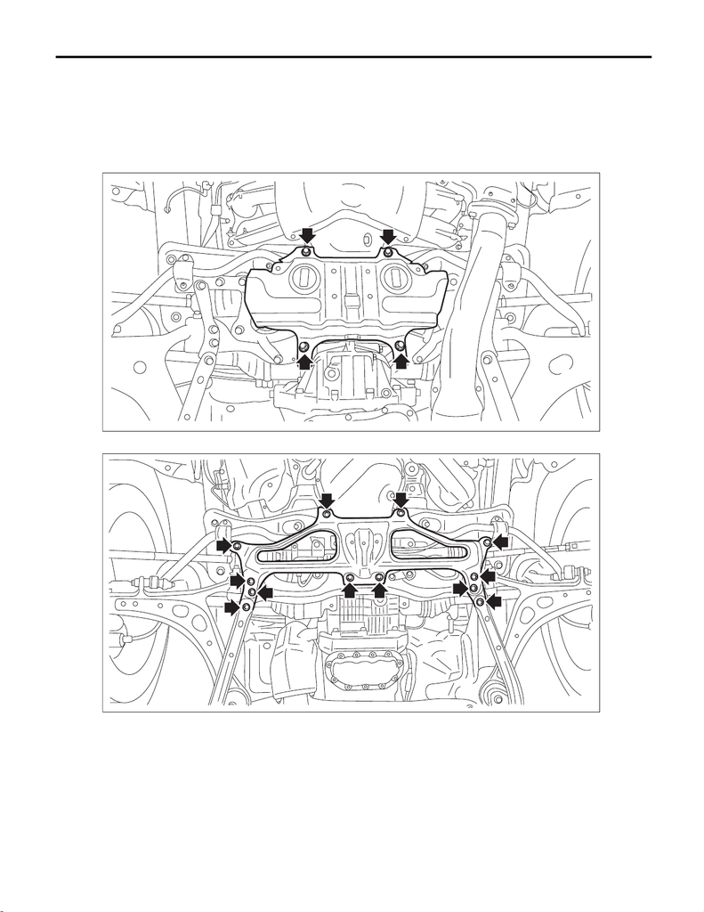

Front Crossmember Support Plate

FRONT SUSPENSION

4. Front Crossmember Support Plate

A: REMOVAL

1) Lift up the vehicle.

2) Remove the under cover - front. <Ref. to EI-21, REMOVAL, Front Under Cover.>

3) Remove the bolt, and remove the front crossmember support.

• Electric power steering model

• Hydraulic power steering model

FS-00660

PS-01732

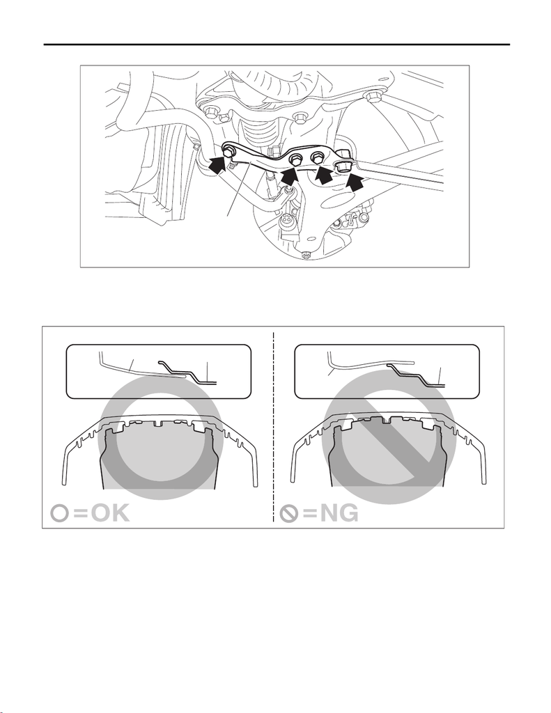

Front Crossmember Support Plate

FRONT SUSPENSION

4) Remove the bolt, and remove the support plate - front crossmember (a).

B: INSTALLATION

CAUTION:

face - front (a).

1) Install the front crossmember support and the support plate - front crossmember.

Tightening torque:

NENT, General Description.>

2) Install the under cover - front. <Ref. to EI-22, INSTALLATION, Front Under Cover.>

3) Lower the vehicle.

PS-01327

EI-04291

(a)

(b)

(a)